# Notat - registrere økologisk tilstand i felt

Sist oppdatert: 2022-02-07 09:03:42

# Registrer økologisk tilstand i felt

Dersom en skal beregne økologsik tilstand etter fagsystemet vil dette av flere grunner ha begrenset oppløsning, og derfor begreset nytteverdi for arealbruksvurderinger i kommunene. Det som kan være en løsning for å dekke dette behovet er lokal datainnsamling av tilpassede tilstandsindikatorer knyttet til naturtyper eller arealtyper. Det beste eksempelt på dette som vi vet om er [the biodiversity metric](http://nepubprod.appspot.com/publication/6049804846366720).

## The Biodiversity Metric

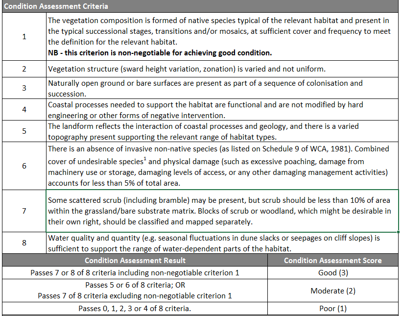

## Naturtyper etter Miljødirektoratets Instruks

Ett annet eksempel på feltregistreringer av tilstand er naturtyper etter Miljødirektoratets instruks hvor tilstand er registrert i felt på grunnlag av en liste med kriterier (typisk 2-4 kriterier). Hvert av disse kriteriene er på en måte en indikator i seg selv, men det er noe problematisk å behandle de som individuelle indikatorer . Det er derimot andre utfordringer med dette datasette knyttet til dekkningsgraden og arealrepresntativiteten. De eksisterende dataene vil ikke dekke behovet for å vurdere de tolv byggeområdene mot hverande. Dette datasetet viser derimot forkomster av økologisk viktige og rødlistede naturtyper, som bør vurderes i arealbrukssaker på lik linje med artsfunn og lignende punktinformasjon som finnes i portalen for økologiske grunnkart.